# Risk Factor Analysis

## Outcome Variable

**Outcome Variable:** wast_rec90d

## Predictor Variables

**Intervention Variable:** earlybf

**Adjustment Set:**

- arm
- sex
- W_mage
- meducyrs
- feducyrs
- hhwealth_quart
- hfoodsec
- W_mhtcm
- W_mwtkg
- W_mbmi
- vagbrth
- W_birthwt
- W_birthlen
- W_nrooms
- W_nchldlt5
- brthmon
- W_parity
- impfloor
- impsan
- safeh20
- delta_W_mage
- delta_meducyrs
- delta_feducyrs
- delta_hhwealth_quart
- delta_hfoodsec
- delta_W_mhtcm
- delta_W_mwtkg
- delta_W_mbmi
- delta_vagbrth
- delta_W_birthwt
- delta_W_birthlen
- delta_W_nrooms
- delta_W_nchldlt5
- delta_brthmon
- delta_W_parity
- delta_impfloor
- delta_impsan
- delta_safeh20

## Stratifying Variables

The analysis was stratified on these variable(s):

- agecat
- studyid
- country

## Data Summary

| agecat | studyid | country | earlybf | wast_rec90d | n_cell | n |
| --- | --- | --- | --- | --- | --- | --- |
| 0-24 months | EE | PAKISTAN | 1 | 0 | 25 | 314 |
| 0-24 months | EE | PAKISTAN | 1 | 1 | 30 | 314 |
| 0-24 months | EE | PAKISTAN | 0 | 0 | 130 | 314 |
| 0-24 months | EE | PAKISTAN | 0 | 1 | 129 | 314 |
| 0-24 months | GMS-Nepal | NEPAL | 1 | 0 | 67 | 582 |
| 0-24 months | GMS-Nepal | NEPAL | 1 | 1 | 94 | 582 |
| 0-24 months | GMS-Nepal | NEPAL | 0 | 0 | 199 | 582 |
| 0-24 months | GMS-Nepal | NEPAL | 0 | 1 | 222 | 582 |
| 0-24 months | JiVitA-3 | BANGLADESH | 1 | 0 | 43 | 7562 |
| 0-24 months | JiVitA-3 | BANGLADESH | 1 | 1 | 13 | 7562 |
| 0-24 months | JiVitA-3 | BANGLADESH | 0 | 0 | 4323 | 7562 |
| 0-24 months | JiVitA-3 | BANGLADESH | 0 | 1 | 3183 | 7562 |
| 0-24 months | JiVitA-4 | BANGLADESH | 1 | 0 | 958 | 2069 |
| 0-24 months | JiVitA-4 | BANGLADESH | 1 | 1 | 357 | 2069 |
| 0-24 months | JiVitA-4 | BANGLADESH | 0 | 0 | 576 | 2069 |
| 0-24 months | JiVitA-4 | BANGLADESH | 0 | 1 | 178 | 2069 |
| 0-24 months | MAL-ED | BANGLADESH | 1 | 0 | 25 | 122 |
| 0-24 months | MAL-ED | BANGLADESH | 1 | 1 | 46 | 122 |
| 0-24 months | MAL-ED | BANGLADESH | 0 | 0 | 18 | 122 |
| 0-24 months | MAL-ED | BANGLADESH | 0 | 1 | 33 | 122 |
| 0-24 months | MAL-ED | BRAZIL | 1 | 0 | 3 | 24 |
| 0-24 months | MAL-ED | BRAZIL | 1 | 1 | 6 | 24 |
| 0-24 months | MAL-ED | BRAZIL | 0 | 0 | 3 | 24 |
| 0-24 months | MAL-ED | BRAZIL | 0 | 1 | 12 | 24 |
| 0-24 months | MAL-ED | INDIA | 1 | 0 | 44 | 181 |
| 0-24 months | MAL-ED | INDIA | 1 | 1 | 63 | 181 |
| 0-24 months | MAL-ED | INDIA | 0 | 0 | 27 | 181 |
| 0-24 months | MAL-ED | INDIA | 0 | 1 | 47 | 181 |
| 0-24 months | MAL-ED | NEPAL | 1 | 0 | 9 | 98 |
| 0-24 months | MAL-ED | NEPAL | 1 | 1 | 33 | 98 |

[output cut: 138 more lines]

The following strata were considered:

- agecat: 0-24 months, studyid: EE, country: PAKISTAN
- agecat: 0-24 months, studyid: GMS-Nepal, country: NEPAL
- agecat: 0-24 months, studyid: JiVitA-3, country: BANGLADESH
- agecat: 0-24 months, studyid: JiVitA-4, country: BANGLADESH
- agecat: 0-24 months, studyid: MAL-ED, country: BANGLADESH
- agecat: 0-24 months, studyid: MAL-ED, country: BRAZIL
- agecat: 0-24 months, studyid: MAL-ED, country: INDIA
- agecat: 0-24 months, studyid: MAL-ED, country: NEPAL
- agecat: 0-24 months, studyid: MAL-ED, country: PERU
- agecat: 0-24 months, studyid: MAL-ED, country: SOUTH AFRICA
- agecat: 0-24 months, studyid: MAL-ED, country: TANZANIA, UNITED REPUBLIC OF
- agecat: 0-24 months, studyid: NIH-Crypto, country: BANGLADESH
- agecat: 0-24 months, studyid: SAS-CompFeed, country: INDIA
- agecat: 0-24 months, studyid: ZVITAMBO, country: ZIMBABWE
- agecat: 0-6 months, studyid: EE, country: PAKISTAN
- agecat: 0-6 months, studyid: GMS-Nepal, country: NEPAL
- agecat: 0-6 months, studyid: JiVitA-3, country: BANGLADESH
- agecat: 0-6 months, studyid: JiVitA-4, country: BANGLADESH
- agecat: 0-6 months, studyid: MAL-ED, country: BANGLADESH
- agecat: 0-6 months, studyid: MAL-ED, country: BRAZIL
- agecat: 0-6 months, studyid: MAL-ED, country: INDIA
- agecat: 0-6 months, studyid: MAL-ED, country: NEPAL
- agecat: 0-6 months, studyid: MAL-ED, country: PERU
- agecat: 0-6 months, studyid: MAL-ED, country: SOUTH AFRICA
- agecat: 0-6 months, studyid: MAL-ED, country: TANZANIA, UNITED REPUBLIC OF
- agecat: 0-6 months, studyid: NIH-Crypto, country: BANGLADESH
- agecat: 0-6 months, studyid: SAS-CompFeed, country: INDIA
- agecat: 0-6 months, studyid: ZVITAMBO, country: ZIMBABWE
- agecat: 6-24 months, studyid: EE, country: PAKISTAN
- agecat: 6-24 months, studyid: GMS-Nepal, country: NEPAL
- agecat: 6-24 months, studyid: JiVitA-3, country: BANGLADESH
- agecat: 6-24 months, studyid: JiVitA-4, country: BANGLADESH
- agecat: 6-24 months, studyid: MAL-ED, country: BANGLADESH
- agecat: 6-24 months, studyid: MAL-ED, country: BRAZIL
- agecat: 6-24 months, studyid: MAL-ED, country: INDIA
- agecat: 6-24 months, studyid: MAL-ED, country: NEPAL
- agecat: 6-24 months, studyid: MAL-ED, country: PERU
- agecat: 6-24 months, studyid: MAL-ED, country: SOUTH AFRICA
- agecat: 6-24 months, studyid: MAL-ED, country: TANZANIA, UNITED REPUBLIC OF
- agecat: 6-24 months, studyid: NIH-Crypto, country: BANGLADESH
- agecat: 6-24 months, studyid: SAS-CompFeed, country: INDIA
- agecat: 6-24 months, studyid: ZVITAMBO, country: ZIMBABWE

### Dropped Strata

Some strata were dropped due to rare outcomes:

- agecat: 0-24 months, studyid: MAL-ED, country: BRAZIL
- agecat: 0-24 months, studyid: MAL-ED, country: PERU
- agecat: 0-24 months, studyid: MAL-ED, country: TANZANIA, UNITED REPUBLIC OF
- agecat: 0-6 months, studyid: MAL-ED, country: BRAZIL
- agecat: 0-6 months, studyid: MAL-ED, country: NEPAL
- agecat: 0-6 months, studyid: MAL-ED, country: PERU
- agecat: 0-6 months, studyid: MAL-ED, country: SOUTH AFRICA
- agecat: 0-6 months, studyid: MAL-ED, country: TANZANIA, UNITED REPUBLIC OF
- agecat: 6-24 months, studyid: JiVitA-3, country: BANGLADESH
- agecat: 6-24 months, studyid: MAL-ED, country: BRAZIL
- agecat: 6-24 months, studyid: MAL-ED, country: NEPAL
- agecat: 6-24 months, studyid: MAL-ED, country: PERU
- agecat: 6-24 months, studyid: MAL-ED, country: SOUTH AFRICA
- agecat: 6-24 months, studyid: MAL-ED, country: TANZANIA, UNITED REPUBLIC OF
- agecat: 6-24 months, studyid: NIH-Crypto, country: BANGLADESH

## Methods Detail

We’re interested in the causal parameters $E[Y_a]$ for all values of $a \in \mathcal{A}$. These parameters represent the mean outcome if, possibly contrary to fact, we intervened to set all units to have $A=a$. Under the randomization and positivity assumptions, these are identified by the statistical parameters $\psi_a=E_W[E_{Y|A,W}(Y|A=a,W)]$. In addition, we’re interested in the mean of $Y$, $E[Y]$ under no intervention (the observed mean). We will estimate these parameters by using SuperLearner to fit the relevant likelihood factors – $E_{Y|A,W}(Y|A=a,W)$ and $p(A=a|W)$, and then updating our likelihood fit using a joint TMLE.

For unadjusted analyses ($W=\{\}$), initial likelihoods were estimated using Lrnr_glm to estimate the simple $E(Y|A)$ and Lrnr_mean to estimate $p(A)$. For adjusted analyses, a small library containing Lrnr_glmnet, Lrnr_xgboost, and Lrnr_mean was used.

Having estimated these parameters, we will then use the delta method to estimate relative risks and attributable risks relative to a prespecified baseline level of $A$.

# Results Detail

## Results Plots

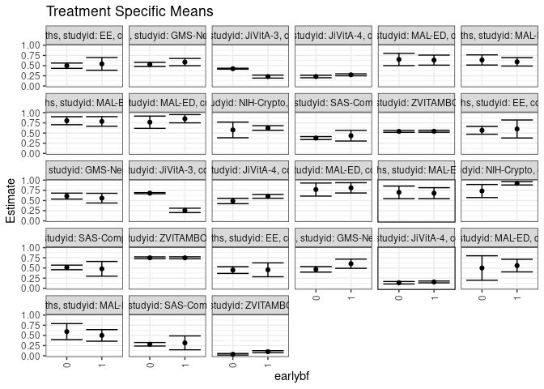

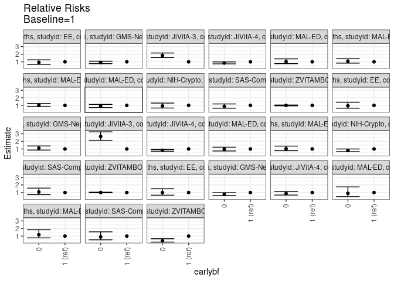

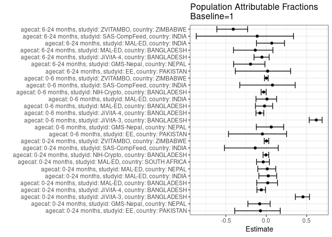

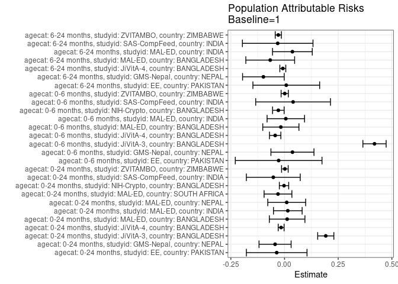

## Results Table

### Parameter: TSM

| agecat | studyid | country | intervention_level | baseline_level | estimate | ci_lower | ci_upper |
| --- | --- | --- | --- | --- | --- | --- | --- |
| 0-24 months | EE | PAKISTAN | 1 | NA | 0.5428388 | 0.3865526 | 0.6991250 |
| 0-24 months | EE | PAKISTAN | 0 | NA | 0.4978961 | 0.4326969 | 0.5630954 |
| 0-24 months | GMS-Nepal | NEPAL | 1 | NA | 0.5869876 | 0.4972550 | 0.6767201 |
| 0-24 months | GMS-Nepal | NEPAL | 0 | NA | 0.5290270 | 0.4779653 | 0.5800887 |
| 0-24 months | JiVitA-3 | BANGLADESH | 1 | NA | 0.2305724 | 0.1937263 | 0.2674186 |
| 0-24 months | JiVitA-3 | BANGLADESH | 0 | NA | 0.4241262 | 0.4127616 | 0.4354908 |
| 0-24 months | JiVitA-4 | BANGLADESH | 1 | NA | 0.2743716 | 0.2505870 | 0.2981562 |
| 0-24 months | JiVitA-4 | BANGLADESH | 0 | NA | 0.2321087 | 0.2012800 | 0.2629374 |
| 0-24 months | MAL-ED | BANGLADESH | 1 | NA | 0.6353639 | 0.5121639 | 0.7585639 |
| 0-24 months | MAL-ED | BANGLADESH | 0 | NA | 0.6506404 | 0.4998907 | 0.8013901 |
| 0-24 months | MAL-ED | INDIA | 1 | NA | 0.5924360 | 0.4892393 | 0.6956327 |
| 0-24 months | MAL-ED | INDIA | 0 | NA | 0.6385989 | 0.5135939 | 0.7636039 |
| 0-24 months | MAL-ED | NEPAL | 1 | NA | 0.7857143 | 0.6676859 | 0.9037426 |
| 0-24 months | MAL-ED | NEPAL | 0 | NA | 0.8035714 | 0.7055573 | 0.9015856 |
| 0-24 months | MAL-ED | SOUTH AFRICA | 1 | NA | 0.8518519 | 0.7511196 | 0.9525841 |
| 0-24 months | MAL-ED | SOUTH AFRICA | 0 | NA | 0.7666667 | 0.6158718 | 0.9174615 |
| 0-24 months | NIH-Crypto | BANGLADESH | 1 | NA | 0.6249639 | 0.5686078 | 0.6813199 |
| 0-24 months | NIH-Crypto | BANGLADESH | 0 | NA | 0.5767030 | 0.3842875 | 0.7691185 |
| 0-24 months | SAS-CompFeed | INDIA | 1 | NA | 0.4349880 | 0.3042980 | 0.5656781 |
| 0-24 months | SAS-CompFeed | INDIA | 0 | NA | 0.3770800 | 0.3405105 | 0.4136495 |
| 0-24 months | ZVITAMBO | ZIMBABWE | 1 | NA | 0.5441886 | 0.5210998 | 0.5672775 |
| 0-24 months | ZVITAMBO | ZIMBABWE | 0 | NA | 0.5414189 | 0.5188816 | 0.5639562 |
| 0-6 months | EE | PAKISTAN | 1 | NA | 0.6000000 | 0.3790586 | 0.8209414 |
| 0-6 months | EE | PAKISTAN | 0 | NA | 0.5673077 | 0.4716455 | 0.6629699 |
| 0-6 months | GMS-Nepal | NEPAL | 1 | NA | 0.5581674 | 0.4383791 | 0.6779557 |
| 0-6 months | GMS-Nepal | NEPAL | 0 | NA | 0.6083260 | 0.5347578 | 0.6818943 |
| 0-6 months | JiVitA-3 | BANGLADESH | 1 | NA | 0.2572980 | 0.2035185 | 0.3110775 |
| 0-6 months | JiVitA-3 | BANGLADESH | 0 | NA | 0.6809787 | 0.6674232 | 0.6945341 |
| 0-6 months | JiVitA-4 | BANGLADESH | 1 | NA | 0.6023656 | 0.5561313 | 0.6485998 |
| 0-6 months | JiVitA-4 | BANGLADESH | 0 | NA | 0.4885086 | 0.4219814 | 0.5550357 |
| 0-6 months | MAL-ED | BANGLADESH | 1 | NA | 0.8108108 | 0.6848512 | 0.9367704 |
| 0-6 months | MAL-ED | BANGLADESH | 0 | NA | 0.7692308 | 0.6087603 | 0.9297013 |
| 0-6 months | MAL-ED | INDIA | 1 | NA | 0.6800526 | 0.5454731 | 0.8146321 |
| 0-6 months | MAL-ED | INDIA | 0 | NA | 0.7002076 | 0.5455849 | 0.8548303 |
| 0-6 months | NIH-Crypto | BANGLADESH | 1 | NA | 0.9221557 | 0.8810188 | 0.9632926 |
| 0-6 months | NIH-Crypto | BANGLADESH | 0 | NA | 0.7333333 | 0.5730566 | 0.8936101 |
| 0-6 months | SAS-CompFeed | INDIA | 1 | NA | 0.4793866 | 0.2984048 | 0.6603684 |
| 0-6 months | SAS-CompFeed | INDIA | 0 | NA | 0.5133812 | 0.4570110 | 0.5697514 |
| 0-6 months | ZVITAMBO | ZIMBABWE | 1 | NA | 0.7488454 | 0.7242660 | 0.7734248 |
| 0-6 months | ZVITAMBO | ZIMBABWE | 0 | NA | 0.7496265 | 0.7268369 | 0.7724160 |
| 6-24 months | EE | PAKISTAN | 1 | NA | 0.4549981 | 0.2845646 | 0.6254315 |
| 6-24 months | EE | PAKISTAN | 0 | NA | 0.4485469 | 0.3656383 | 0.5314555 |
| 6-24 months | GMS-Nepal | NEPAL | 1 | NA | 0.6043319 | 0.4917358 | 0.7169279 |
| 6-24 months | GMS-Nepal | NEPAL | 0 | NA | 0.4667176 | 0.3991801 | 0.5342552 |
| 6-24 months | JiVitA-4 | BANGLADESH | 1 | NA | 0.1570748 | 0.1345264 | 0.1796232 |
| 6-24 months | JiVitA-4 | BANGLADESH | 0 | NA | 0.1369921 | 0.1064283 | 0.1675560 |
| 6-24 months | MAL-ED | BANGLADESH | 1 | NA | 0.5581989 | 0.4032514 | 0.7131465 |
| 6-24 months | MAL-ED | BANGLADESH | 0 | NA | 0.4987995 | 0.1979969 | 0.7996020 |
| 6-24 months | MAL-ED | INDIA | 1 | NA | 0.5001657 | 0.3581428 | 0.6421885 |
| 6-24 months | MAL-ED | INDIA | 0 | NA | 0.5926890 | 0.3955423 | 0.7898358 |
| 6-24 months | SAS-CompFeed | INDIA | 1 | NA | 0.3172484 | 0.1465147 | 0.4879822 |
| 6-24 months | SAS-CompFeed | INDIA | 0 | NA | 0.2830929 | 0.2399783 | 0.3262075 |
| 6-24 months | ZVITAMBO | ZIMBABWE | 1 | NA | 0.1001618 | 0.0751428 | 0.1251807 |
| 6-24 months | ZVITAMBO | ZIMBABWE | 0 | NA | 0.0371973 | 0.0183744 | 0.0560203 |

### Parameter: E(Y)

| agecat | studyid | country | intervention_level | baseline_level | estimate | ci_lower | ci_upper |
| --- | --- | --- | --- | --- | --- | --- | --- |
| 0-24 months | EE | PAKISTAN | NA | NA | 0.5063694 | 0.4463277 | 0.5664112 |
| 0-24 months | GMS-Nepal | NEPAL | NA | NA | 0.5429553 | 0.4984173 | 0.5874934 |
| 0-24 months | JiVitA-3 | BANGLADESH | NA | NA | 0.4226395 | 0.4115112 | 0.4337678 |
| 0-24 months | JiVitA-4 | BANGLADESH | NA | NA | 0.2585790 | 0.2392503 | 0.2779077 |
| 0-24 months | MAL-ED | BANGLADESH | NA | NA | 0.6475410 | 0.5607680 | 0.7343140 |
| 0-24 months | MAL-ED | INDIA | NA | NA | 0.6077348 | 0.5286689 | 0.6868008 |
| 0-24 months | MAL-ED | NEPAL | NA | NA | 0.7959184 | 0.7207268 | 0.8711100 |
| 0-24 months | MAL-ED | SOUTH AFRICA | NA | NA | 0.8214286 | 0.7371305 | 0.9057266 |
| 0-24 months | NIH-Crypto | BANGLADESH | NA | NA | 0.6225806 | 0.5684562 | 0.6767051 |
| 0-24 months | SAS-CompFeed | INDIA | NA | NA | 0.3827160 | 0.3474971 | 0.4179350 |
| 0-24 months | ZVITAMBO | ZIMBABWE | NA | NA | 0.5458155 | 0.5286072 | 0.5630238 |
| 0-6 months | EE | PAKISTAN | NA | NA | 0.5725806 | 0.4847582 | 0.6604031 |
| 0-6 months | GMS-Nepal | NEPAL | NA | NA | 0.5950413 | 0.5325830 | 0.6574997 |
| 0-6 months | JiVitA-3 | BANGLADESH | NA | NA | 0.6764021 | 0.6630620 | 0.6897422 |
| 0-6 months | JiVitA-4 | BANGLADESH | NA | NA | 0.5587703 | 0.5173487 | 0.6001920 |
| 0-6 months | MAL-ED | BANGLADESH | NA | NA | 0.7936508 | 0.6942781 | 0.8930235 |
| 0-6 months | MAL-ED | INDIA | NA | NA | 0.6860465 | 0.5849088 | 0.7871842 |
| 0-6 months | NIH-Crypto | BANGLADESH | NA | NA | 0.8934010 | 0.8497799 | 0.9370221 |
| 0-6 months | SAS-CompFeed | INDIA | NA | NA | 0.5192878 | 0.4654446 | 0.5731311 |
| 0-6 months | ZVITAMBO | ZIMBABWE | NA | NA | 0.7497817 | 0.7320520 | 0.7675113 |
| 6-24 months | EE | PAKISTAN | NA | NA | 0.4631579 | 0.3886610 | 0.5376548 |
| 6-24 months | GMS-Nepal | NEPAL | NA | NA | 0.5058824 | 0.4476568 | 0.5641079 |
| 6-24 months | JiVitA-4 | BANGLADESH | NA | NA | 0.1490765 | 0.1314900 | 0.1666630 |
| 6-24 months | MAL-ED | BANGLADESH | NA | NA | 0.4915254 | 0.3576698 | 0.6253810 |
| 6-24 months | MAL-ED | INDIA | NA | NA | 0.5368421 | 0.4223932 | 0.6512910 |
| 6-24 months | SAS-CompFeed | INDIA | NA | NA | 0.2854123 | 0.2436284 | 0.3271961 |
| 6-24 months | ZVITAMBO | ZIMBABWE | NA | NA | 0.0711382 | 0.0551795 | 0.0870969 |

### Parameter: RR

| agecat | studyid | country | intervention_level | baseline_level | estimate | ci_lower | ci_upper |
| --- | --- | --- | --- | --- | --- | --- | --- |
| 0-24 months | EE | PAKISTAN | 1 | 1 | 1.0000000 | 1.0000000 | 1.0000000 |
| 0-24 months | EE | PAKISTAN | 0 | 1 | 0.9172080 | 0.6683417 | 1.2587431 |
| 0-24 months | GMS-Nepal | NEPAL | 1 | 1 | 1.0000000 | 1.0000000 | 1.0000000 |
| 0-24 months | GMS-Nepal | NEPAL | 0 | 1 | 0.9012576 | 0.7523125 | 1.0796914 |
| 0-24 months | JiVitA-3 | BANGLADESH | 1 | 1 | 1.0000000 | 1.0000000 | 1.0000000 |
| 0-24 months | JiVitA-3 | BANGLADESH | 0 | 1 | 1.8394489 | 1.5642323 | 2.1630881 |
| 0-24 months | JiVitA-4 | BANGLADESH | 1 | 1 | 1.0000000 | 1.0000000 | 1.0000000 |
| 0-24 months | JiVitA-4 | BANGLADESH | 0 | 1 | 0.8459647 | 0.7260599 | 0.9856711 |
| 0-24 months | MAL-ED | BANGLADESH | 1 | 1 | 1.0000000 | 1.0000000 | 1.0000000 |
| 0-24 months | MAL-ED | BANGLADESH | 0 | 1 | 1.0240437 | 0.7561353 | 1.3868756 |
| 0-24 months | MAL-ED | INDIA | 1 | 1 | 1.0000000 | 1.0000000 | 1.0000000 |
| 0-24 months | MAL-ED | INDIA | 0 | 1 | 1.0779204 | 0.8284190 | 1.4025662 |
| 0-24 months | MAL-ED | NEPAL | 1 | 1 | 1.0000000 | 1.0000000 | 1.0000000 |
| 0-24 months | MAL-ED | NEPAL | 0 | 1 | 1.0227273 | 0.8422004 | 1.2419503 |
| 0-24 months | MAL-ED | SOUTH AFRICA | 1 | 1 | 1.0000000 | 1.0000000 | 1.0000000 |
| 0-24 months | MAL-ED | SOUTH AFRICA | 0 | 1 | 0.9000000 | 0.7153015 | 1.1323896 |
| 0-24 months | NIH-Crypto | BANGLADESH | 1 | 1 | 1.0000000 | 1.0000000 | 1.0000000 |
| 0-24 months | NIH-Crypto | BANGLADESH | 0 | 1 | 0.9227782 | 0.6533252 | 1.3033625 |
| 0-24 months | SAS-CompFeed | INDIA | 1 | 1 | 1.0000000 | 1.0000000 | 1.0000000 |
| 0-24 months | SAS-CompFeed | INDIA | 0 | 1 | 0.8668744 | 0.6324792 | 1.1881357 |
| 0-24 months | ZVITAMBO | ZIMBABWE | 1 | 1 | 1.0000000 | 1.0000000 | 1.0000000 |
| 0-24 months | ZVITAMBO | ZIMBABWE | 0 | 1 | 0.9949103 | 0.9423178 | 1.0504381 |
| 0-6 months | EE | PAKISTAN | 1 | 1 | 1.0000000 | 1.0000000 | 1.0000000 |
| 0-6 months | EE | PAKISTAN | 0 | 1 | 0.9455128 | 0.6306298 | 1.4176218 |
| 0-6 months | GMS-Nepal | NEPAL | 1 | 1 | 1.0000000 | 1.0000000 | 1.0000000 |
| 0-6 months | GMS-Nepal | NEPAL | 0 | 1 | 1.0898631 | 0.8522827 | 1.3936708 |
| 0-6 months | JiVitA-3 | BANGLADESH | 1 | 1 | 1.0000000 | 1.0000000 | 1.0000000 |
| 0-6 months | JiVitA-3 | BANGLADESH | 0 | 1 | 2.6466534 | 2.1454453 | 3.2649512 |
| 0-6 months | JiVitA-4 | BANGLADESH | 1 | 1 | 1.0000000 | 1.0000000 | 1.0000000 |
| 0-6 months | JiVitA-4 | BANGLADESH | 0 | 1 | 0.8109835 | 0.7029858 | 0.9355727 |
| 0-6 months | MAL-ED | BANGLADESH | 1 | 1 | 1.0000000 | 1.0000000 | 1.0000000 |
| 0-6 months | MAL-ED | BANGLADESH | 0 | 1 | 0.9487179 | 0.7314256 | 1.2305636 |
| 0-6 months | MAL-ED | INDIA | 1 | 1 | 1.0000000 | 1.0000000 | 1.0000000 |
| 0-6 months | MAL-ED | INDIA | 0 | 1 | 1.0296374 | 0.7708861 | 1.3752395 |
| 0-6 months | NIH-Crypto | BANGLADESH | 1 | 1 | 1.0000000 | 1.0000000 | 1.0000000 |
| 0-6 months | NIH-Crypto | BANGLADESH | 0 | 1 | 0.7952381 | 0.6362402 | 0.9939699 |
| 0-6 months | SAS-CompFeed | INDIA | 1 | 1 | 1.0000000 | 1.0000000 | 1.0000000 |
| 0-6 months | SAS-CompFeed | INDIA | 0 | 1 | 1.0709127 | 0.7229798 | 1.5862877 |
| 0-6 months | ZVITAMBO | ZIMBABWE | 1 | 1 | 1.0000000 | 1.0000000 | 1.0000000 |
| 0-6 months | ZVITAMBO | ZIMBABWE | 0 | 1 | 1.0010431 | 0.9603864 | 1.0434208 |
| 6-24 months | EE | PAKISTAN | 1 | 1 | 1.0000000 | 1.0000000 | 1.0000000 |
| 6-24 months | EE | PAKISTAN | 0 | 1 | 0.9858215 | 0.6488165 | 1.4978721 |
| 6-24 months | GMS-Nepal | NEPAL | 1 | 1 | 1.0000000 | 1.0000000 | 1.0000000 |
| 6-24 months | GMS-Nepal | NEPAL | 0 | 1 | 0.7722870 | 0.6102056 | 0.9774200 |
| 6-24 months | JiVitA-4 | BANGLADESH | 1 | 1 | 1.0000000 | 1.0000000 | 1.0000000 |
| 6-24 months | JiVitA-4 | BANGLADESH | 0 | 1 | 0.8721459 | 0.6687540 | 1.1373966 |
| 6-24 months | MAL-ED | BANGLADESH | 1 | 1 | 1.0000000 | 1.0000000 | 1.0000000 |
| 6-24 months | MAL-ED | BANGLADESH | 0 | 1 | 0.8935873 | 0.4581264 | 1.7429651 |
| 6-24 months | MAL-ED | INDIA | 1 | 1 | 1.0000000 | 1.0000000 | 1.0000000 |
| 6-24 months | MAL-ED | INDIA | 0 | 1 | 1.1849854 | 0.7629713 | 1.8404236 |
| 6-24 months | SAS-CompFeed | INDIA | 1 | 1 | 1.0000000 | 1.0000000 | 1.0000000 |
| 6-24 months | SAS-CompFeed | INDIA | 0 | 1 | 0.8923382 | 0.5101480 | 1.5608559 |
| 6-24 months | ZVITAMBO | ZIMBABWE | 1 | 1 | 1.0000000 | 1.0000000 | 1.0000000 |
| 6-24 months | ZVITAMBO | ZIMBABWE | 0 | 1 | 0.3713724 | 0.2112993 | 0.6527115 |

### Parameter: PAR

| agecat | studyid | country | intervention_level | baseline_level | estimate | ci_lower | ci_upper |
| --- | --- | --- | --- | --- | --- | --- | --- |
| 0-24 months | EE | PAKISTAN | 1 | NA | -0.0364694 | -0.1776971 | 0.1047583 |
| 0-24 months | GMS-Nepal | NEPAL | 1 | NA | -0.0440323 | -0.1187801 | 0.0307156 |
| 0-24 months | JiVitA-3 | BANGLADESH | 1 | NA | 0.1920671 | 0.1544223 | 0.2297119 |
| 0-24 months | JiVitA-4 | BANGLADESH | 1 | NA | -0.0157926 | -0.0294713 | -0.0021139 |
| 0-24 months | MAL-ED | BANGLADESH | 1 | NA | 0.0121771 | -0.0706531 | 0.0950073 |
| 0-24 months | MAL-ED | INDIA | 1 | NA | 0.0152988 | -0.0514192 | 0.0820167 |
| 0-24 months | MAL-ED | NEPAL | 1 | NA | 0.0102041 | -0.0780591 | 0.0984672 |
| 0-24 months | MAL-ED | SOUTH AFRICA | 1 | NA | -0.0304233 | -0.0951285 | 0.0342819 |
| 0-24 months | NIH-Crypto | BANGLADESH | 1 | NA | -0.0023832 | -0.0242016 | 0.0194352 |
| 0-24 months | SAS-CompFeed | INDIA | 1 | NA | -0.0522720 | -0.1777888 | 0.0732449 |
| 0-24 months | ZVITAMBO | ZIMBABWE | 1 | NA | 0.0016269 | -0.0137570 | 0.0170108 |
| 0-6 months | EE | PAKISTAN | 1 | NA | -0.0274194 | -0.2293626 | 0.1745239 |
| 0-6 months | GMS-Nepal | NEPAL | 1 | NA | 0.0368739 | -0.0633562 | 0.1371040 |
| 0-6 months | JiVitA-3 | BANGLADESH | 1 | NA | 0.4191041 | 0.3649622 | 0.4732460 |
| 0-6 months | JiVitA-4 | BANGLADESH | 1 | NA | -0.0435952 | -0.0700330 | -0.0171574 |
| 0-6 months | MAL-ED | BANGLADESH | 1 | NA | -0.0171600 | -0.1014153 | 0.0670952 |
| 0-6 months | MAL-ED | INDIA | 1 | NA | 0.0059939 | -0.0812488 | 0.0932366 |
| 0-6 months | NIH-Crypto | BANGLADESH | 1 | NA | -0.0287547 | -0.0557185 | -0.0017909 |
| 0-6 months | SAS-CompFeed | INDIA | 1 | NA | 0.0399012 | -0.1342697 | 0.2140721 |
| 0-6 months | ZVITAMBO | ZIMBABWE | 1 | NA | 0.0009363 | -0.0159940 | 0.0178666 |
| 6-24 months | EE | PAKISTAN | 1 | NA | 0.0081598 | -0.1472852 | 0.1636048 |
| 6-24 months | GMS-Nepal | NEPAL | 1 | NA | -0.0984495 | -0.1954526 | -0.0014464 |
| 6-24 months | JiVitA-4 | BANGLADESH | 1 | NA | -0.0079983 | -0.0218694 | 0.0058729 |
| 6-24 months | MAL-ED | BANGLADESH | 1 | NA | -0.0666735 | -0.1803595 | 0.0470125 |
| 6-24 months | MAL-ED | INDIA | 1 | NA | 0.0366764 | -0.0559209 | 0.1292738 |
| 6-24 months | SAS-CompFeed | INDIA | 1 | NA | -0.0318361 | -0.1962388 | 0.1325665 |
| 6-24 months | ZVITAMBO | ZIMBABWE | 1 | NA | -0.0290236 | -0.0434231 | -0.0146240 |

### Parameter: PAF

| agecat | studyid | country | intervention_level | baseline_level | estimate | ci_lower | ci_upper |
| --- | --- | --- | --- | --- | --- | --- | --- |
| 0-24 months | EE | PAKISTAN | 1 | NA | -0.0720213 | -0.3901641 | 0.1733136 |
| 0-24 months | GMS-Nepal | NEPAL | 1 | NA | -0.0810974 | -0.2275519 | 0.0478842 |
| 0-24 months | JiVitA-3 | BANGLADESH | 1 | NA | 0.4544466 | 0.3598473 | 0.5350664 |
| 0-24 months | JiVitA-4 | BANGLADESH | 1 | NA | -0.0610746 | -0.1154765 | -0.0093258 |
| 0-24 months | MAL-ED | BANGLADESH | 1 | NA | 0.0188051 | -0.1180078 | 0.1388759 |
| 0-24 months | MAL-ED | INDIA | 1 | NA | 0.0251734 | -0.0910645 | 0.1290278 |
| 0-24 months | MAL-ED | NEPAL | 1 | NA | 0.0128205 | -0.1045999 | 0.1177590 |
| 0-24 months | MAL-ED | SOUTH AFRICA | 1 | NA | -0.0370370 | -0.1194057 | 0.0392707 |
| 0-24 months | NIH-Crypto | BANGLADESH | 1 | NA | -0.0038280 | -0.0395271 | 0.0306452 |
| 0-24 months | SAS-CompFeed | INDIA | 1 | NA | -0.1365816 | -0.5169218 | 0.1483953 |
| 0-24 months | ZVITAMBO | ZIMBABWE | 1 | NA | 0.0029807 | -0.0256069 | 0.0307714 |
| 0-6 months | EE | PAKISTAN | 1 | NA | -0.0478873 | -0.4672027 | 0.2515909 |
| 0-6 months | GMS-Nepal | NEPAL | 1 | NA | 0.0619687 | -0.1229445 | 0.2164326 |
| 0-6 months | JiVitA-3 | BANGLADESH | 1 | NA | 0.6196079 | 0.5316394 | 0.6910540 |
| 0-6 months | JiVitA-4 | BANGLADESH | 1 | NA | -0.0780199 | -0.1275096 | -0.0307025 |
| 0-6 months | MAL-ED | BANGLADESH | 1 | NA | -0.0216216 | -0.1337321 | 0.0794027 |
| 0-6 months | MAL-ED | INDIA | 1 | NA | 0.0087368 | -0.1269778 | 0.1281082 |
| 0-6 months | NIH-Crypto | BANGLADESH | 1 | NA | -0.0321856 | -0.0634921 | -0.0018007 |
| 0-6 months | SAS-CompFeed | INDIA | 1 | NA | 0.0768383 | -0.3274382 | 0.3579908 |
| 0-6 months | ZVITAMBO | ZIMBABWE | 1 | NA | 0.0012487 | -0.0215890 | 0.0235759 |
| 6-24 months | EE | PAKISTAN | 1 | NA | 0.0176178 | -0.3823615 | 0.3018651 |
| 6-24 months | GMS-Nepal | NEPAL | 1 | NA | -0.1946095 | -0.4044203 | -0.0161430 |
| 6-24 months | JiVitA-4 | BANGLADESH | 1 | NA | -0.0536521 | -0.1510709 | 0.0355217 |
| 6-24 months | MAL-ED | BANGLADESH | 1 | NA | -0.1356461 | -0.4057042 | 0.0825295 |
| 6-24 months | MAL-ED | INDIA | 1 | NA | 0.0683188 | -0.1206626 | 0.2254316 |
| 6-24 months | SAS-CompFeed | INDIA | 1 | NA | -0.1115444 | -0.8659510 | 0.3378545 |
| 6-24 months | ZVITAMBO | ZIMBABWE | 1 | NA | -0.4079882 | -0.6115076 | -0.2301716 |